# **Advanced Machine Learning: EasyVisa (Visa Application Processing)**

### **Model Observation Summary**

- Hyperparameter tuning enhanced the model's overall performance on unseen data, particularly in precision and F1 score.
- Lower training scores indicate that the model has successfully reduced its tendency to overfit the training dataset.
- A slight gap remains between training and validation results, but this overfitting is significantly less severe than before tuning.

### **Importances**

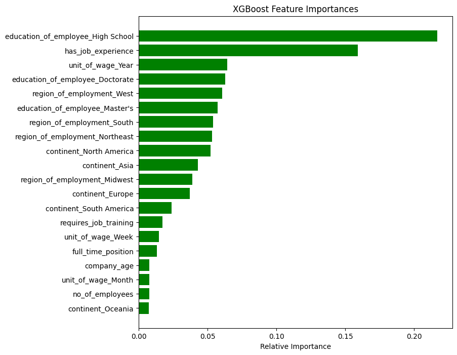

```python
# Compute and print the important features
xgb_importances = xg_boost_classifier_tuned.feature_importances_
xgb_indices = np.argsort(xgb_importances)
xgb_feature_names = list(X.columns)

# Plot the feature importance
plt.figure(figsize=(8,8))
plt.title('XGBoost Feature Importances')
plt.barh(range(len(xgb_indices)), xgb_importances[xgb_indices], color='green', align='center')
plt.yticks(range(len(xgb_indices)), [xgb_feature_names[i] for i in xgb_indices])
plt.xlabel('Relative Importance')
plt.show()
```

### **Compare hyperparameter tuned models**

### **Listing the models**

```python
# Create the matrix to display the techniques and the models with their performance on training and testing data
hpt_model_names = [
    'Ada Boost Oversampled',
    'Ada Boost hyperparameter tuned',
    'Gradient Boost Oversampled',
    'Gradient Boost hyperparameter tuned',
    'XGBoost Oversampled',
    'XGBoost hyperparameter tuned'
]

hpt_models = pd.concat([
    ada_boost_classifier_oversampled_performance,
    ada_boost_classifier_tuned_performance,
    gradient_boost_classifier_oversampled_performance,
    gradient_boost_classifier_tuned_performance,
    xg_boost_classifier_oversampled_performance,
    xg_boost_classifier_tuned_performance
], axis=0, keys = hpt_model_names)
hpt_models
```

|  |  |  | Accuracy | Recall | Precision | F1 |
| --- | --- | --- | --- | --- | --- | --- |
| Ada Boost Oversampled | Training | 0 | 0.742014 | 0.535773 | 0.749712 | 0.624940 |
|  | Validation | 0 | 0.735835 | 0.464549 | 0.641182 | 0.538758 |
| Ada Boost hyperparameter tuned | Training | 0 | 0.765932 | 0.637884 | 0.742383 | 0.686178 |
|  | Validation | 0 | 0.743194 | 0.549483 | 0.629975 | 0.586982 |
| Gradient Boost Oversampled | Training | 0 | 0.767966 | 0.632264 | 0.750081 | 0.686152 |
|  | Validation | 0 | 0.745892 | 0.538405 | 0.639474 | 0.584603 |
| Gradient Boost hyperparameter tuned | Training | 0 | 0.772750 | 0.633361 | 0.760158 | 0.690991 |
|  | Validation | 0 | 0.745646 | 0.528065 | 0.642408 | 0.579651 |
| XGBoost Oversampled | Training | 0 | 0.829329 | 0.710389 | 0.839488 | 0.769562 |
|  | Validation | 0 | 0.731175 | 0.505908 | 0.616007 | 0.555556 |
| XGBoost hyperparameter tuned | Training | 0 | 0.777313 | 0.640488 | 0.766066 | 0.697671 |
|  | Validation | 0 | 0.746382 | 0.533235 | 0.642349 | 0.582728 |

### **Observations on hyperparameter models**

Here are the performance results for the three **hyperparameter-tuned**, oversampled models (**AdaBoost**, **GradientBoost**, and **XGBoost**)

### **1. Best Precision (Validation Set) :**

- GradientBoost : **0.642408**
- XGBoost : 0.642349
- AdaBoost : 0.629975

**Key Observation** : Precision is the important metric for EasyVisa, and GradientBoost performs best in our case.

### **2. Best F1 Score (Validation Set) :**

- AdaBoost : **0.586982**
- XGBoost : 0.582728
- GradientBoost : 0.579651

**Key Observation** : F1 Score is the next important metric (Precision-recall balance), and AdaBoost slightly edges out the other.

### **3. Recall (Balance Check) :**

- AdaBoost : **0.549483**
- XGBoost : 0.533235
- GradientBoost : 0.528065

### **4. Robustness to Overfitting (Gap Analysis) :**

Training vs Validation F1 gap:

- AdaBoost : 0.686178 - 0.586982 (Gap : 0.099196)
- XGBoost : 0.697671 - 0.582728 (Gap : 0.114943)
- GradientBoost : 0.690991 - 0.579651 (Gap : 0.11134)

**Key Observation** : All models generalize similarly well, But AdaBoost having lesser gap than other models.

### **Performance of final model on test data**

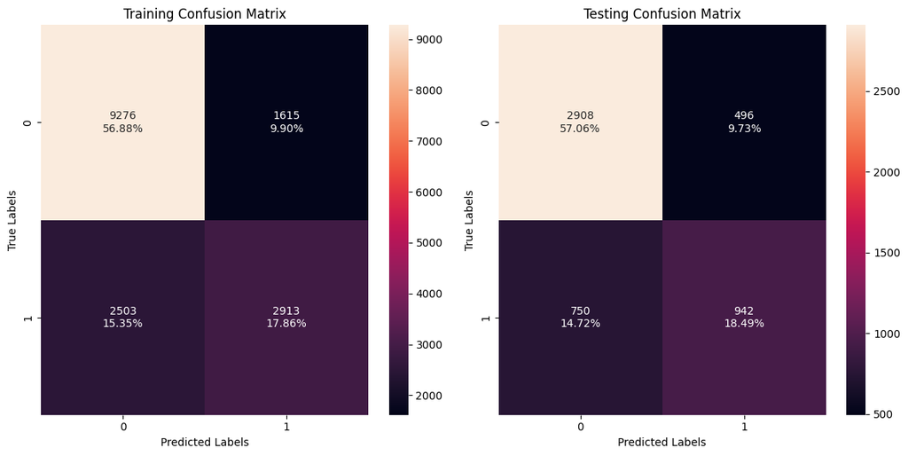

```python
# Plot confusion matrices for training and testing data
plot_confusion_matrices_v2(ada_boost_classifier_tuned, X_train, y_train, X_test, y_test, validation_label="Testing Confusion Matrix")
```

```python
# Compute performance metrics on training data set
ada_boost_classifier_tuned_train_perf = model_performance_classification(ada_boost_classifier_tuned, X_train_over, y_train_over)

# Compute performance metrics on testing data set
ada_boost_classifier_tuned_test_perf = model_performance_classification(ada_boost_classifier_tuned, X_test, y_test)

# Print and compare model performances
ada_boost_classifier_tuned_final_performance = pd.concat([ada_boost_classifier_tuned_train_perf, ada_boost_classifier_tuned_test_perf], axis=0, keys=["Training", "Testing"])
ada_boost_classifier_tuned_final_performance
```

|  |  | Accuracy | Recall | Precision | F1 |
| --- | --- | --- | --- | --- | --- |
| Training | 0 | 0.765932 | 0.637884 | 0.742383 | 0.686178 |
| Testing | 0 | 0.755495 | 0.556738 | 0.655076 | 0.601917 |

### **Model Performance summary on Test Data**

- The test F1 score (0.601) stays relatively close to the training F1 score (0.686), showing that the model transfers well to unseen data.
- A test precision score of 0.655 indicates that the model is effective at minimizing false positives
- Recall decreases moderately from 0.637 to 0.556 on the test set, meaning the model misses a portion of actual positive cases.
- The model demonstrates reliable generalization overall and maintains a strong focus on precision.

# **Actionable Insights & Recommendations**

## **Key Highlights : Business Recommendations**

- **Prioritize Job Experience**: Focus evaluation on applicant work history as a primary success indicator.
- **Filter by Education**: Implement strategic screening based on high-school or qualification levels.
- **Target Regional Demographics**: Focus on Asian applicant profiles within specific US target regions.
- **Target Yearly Wages**: Favor positions offering annual salaries, which correlate with higher approval rates.
- **Exclude Low-Impact Factors**: Streamline processing by dropping features that contribute little predictive value.
- **Deploy for Workload Reduction**: Integrate the model to automate and reduce manual OFLC review volumes.

## **Detailed : Business Recommendations**

**1. Prioritize Job Experience**

- Use work history as a primary positive screening filter for high-probability candidates.
- Strongly favor applicants with prior experience, as it stands as the second-highest predictor (0.15 importance) of visa approval.
- Filter out or lower the priority for candidates lacking work experience, as they show significantly lower approval rates.

**4. Target Yearly Wages**

- Focus on applications with annual salary structures rather than hourly or weekly positions, given their higher predictive importance ($0.07$).
- Treat yearly wages as a positive signal for stable, full-time roles that align with OFLC approval criteria.
- Deprioritize or filter out lower-commitment hourly positions to improve overall approval probability.

**5. Exclude Low-Impact Factors**

- Exclude company size and company age from primary screening criteria due to their minimal predictive power.
- Streamline application evaluations by focusing exclusively on high-importance features.
- Reduce screening complexity to enable faster and more efficient candidate processing.

### **Model Limitations and Business Considerations**

**Model Interpretability and Trust:**

- Maintain transparency with OFLC stakeholders regarding key decision factors (education, experience, geography) and use the model as a decision-support tool rather than a replacement for human reviewers, particularly for complex cases.

**Bias and Fairness Concerns:**

- Mitigate historical OFLC decision biases that may unfairly impact specific groups, ensure compliance with labor fairness laws, and conduct regular audits to maintain equitable treatment.

**Ongoing Maintenance and Data Quality:**

- Retrain the model every 6 to 12 months to adapt to evolving policies, establish feedback loops for incorrectly rejected applications, and address data inconsistencies like prevailing wage outliers and missing context.